# CH5 : Decision Trees & Random Forests

TP6 : classification tree

> In this practical work, we will build some decision trees for classification problems. Note that there are many packages to do this in `R` . The tree package is the basic package to do so, while the `rpart17` package seems more widely suggested and provides better plotting features. So we will use the `rpart` package.

A classification tree is very similar to a regression tree, except that the classification tree is used to predict a qualitative response rather than a quantitative one. Recall that for a regression tree, the predicted response for an observation is given by the mean response of the training observations that belong to the same terminal node. In contrast, for a classification tree, we predict that each observation belongs to the most commonly occurring class of training observations in the region to which it belongs.

To construct classification trees, we will use the spam21 dataset.

This dataset consists of information from 4601 email messages, in a study to try to predict whether the email was junk email, or `spam`. For all 4601 email messages, the true outcome, spam or not, is available, along with `57 predictors` as described below:

- `48 quantitative predictors`: the percentage of words in the email that match a given word. Examples include business, address, internet; etc.
- `6 quantitative predictors`: the percentage of characters in the email that match a given character. The characters are `; , ( , [ , ! , $ and #`.
- The average length of uninterrupted sequences of capital letters: `crl.ave`.
- The length of the longest uninterrupted sequence of capital letters: `crl.long`.
- The sum of the length of uninterrupted sequences of capital letters: `crl.tot`.

# Question 18

For the rest of this PW, you must:

- Import the spam dataset and explore it. Be aware that it is preferable that the response column is of type factor.
- Split the dataset into training and test sets (choose your own seed when using set.seed()).
- Fit (using rpart and gbm packages):
  - A Logistic regression model.
  - A simple classification tree.
  - Bagging
  - Random Forests
  - Boosting models.

For each model, predict the response on the test set and evaluate the performance of the model, using the prediction accuracy (create a function that returns the accuracy for two binary vectors).

```r
library(rpart)
library(rpart.plot)
library(randomForest)
library(gbm)
library(caret)
library(caTools)

spam <- read.csv(file = "spam.csv", header = TRUE, sep = ",")
spam$spam <- ifelse(spam$spam == FALSE,0,1)
summary(spam)
```

```
##       spam            make           address            all
##  Min.   :0.000   Min.   :0.0000   Min.   : 0.000   Min.   :0.0000
##  1st Qu.:0.000   1st Qu.:0.0000   1st Qu.: 0.000   1st Qu.:0.0000
##  Median :0.000   Median :0.0000   Median : 0.000   Median :0.0000
##  Mean   :0.394   Mean   :0.1046   Mean   : 0.213   Mean   :0.2807
##  3rd Qu.:1.000   3rd Qu.:0.0000   3rd Qu.: 0.000   3rd Qu.:0.4200
##  Max.   :1.000   Max.   :4.5400   Max.   :14.280   Max.   :5.1000
##       X3d                our               over            remove
##  Min.   : 0.00000   Min.   : 0.0000   Min.   :0.0000   Min.   :0.0000
##  1st Qu.: 0.00000   1st Qu.: 0.0000   1st Qu.:0.0000   1st Qu.:0.0000
##  Median : 0.00000   Median : 0.0000   Median :0.0000   Median :0.0000
##  Mean   : 0.06542   Mean   : 0.3122   Mean   :0.0959   Mean   :0.1142
##  3rd Qu.: 0.00000   3rd Qu.: 0.3800   3rd Qu.:0.0000   3rd Qu.:0.0000
##  Max.   :42.81000   Max.   :10.0000   Max.   :5.8800   Max.   :7.2700
##     internet           order              mail            receive
##  Min.   : 0.0000   Min.   :0.00000   Min.   : 0.0000   Min.   :0.00000
##  1st Qu.: 0.0000   1st Qu.:0.00000   1st Qu.: 0.0000   1st Qu.:0.00000
##  Median : 0.0000   Median :0.00000   Median : 0.0000   Median :0.00000
##  Mean   : 0.1053   Mean   :0.09007   Mean   : 0.2394   Mean   :0.05982
##  3rd Qu.: 0.0000   3rd Qu.:0.00000   3rd Qu.: 0.1600   3rd Qu.:0.00000
##  Max.   :11.1100   Max.   :5.26000   Max.   :18.1800   Max.   :2.61000
##       will            people            report           addresses
##  Min.   :0.0000   Min.   :0.00000   Min.   : 0.00000   Min.   :0.0000
##  1st Qu.:0.0000   1st Qu.:0.00000   1st Qu.: 0.00000   1st Qu.:0.0000
##  Median :0.1000   Median :0.00000   Median : 0.00000   Median :0.0000
##  Mean   :0.5417   Mean   :0.09393   Mean   : 0.05863   Mean   :0.0492
##  3rd Qu.:0.8000   3rd Qu.:0.00000   3rd Qu.: 0.00000   3rd Qu.:0.0000
##  Max.   :9.6700   Max.   :5.55000   Max.   :10.00000   Max.   :4.4100
##       free            business          email             you
##  Min.   : 0.0000   Min.   :0.0000   Min.   :0.0000   Min.   : 0.000
##  1st Qu.: 0.0000   1st Qu.:0.0000   1st Qu.:0.0000   1st Qu.: 0.000
##  Median : 0.0000   Median :0.0000   Median :0.0000   Median : 1.310
##  Mean   : 0.2488   Mean   :0.1426   Mean   :0.1847   Mean   : 1.662
##  3rd Qu.: 0.1000   3rd Qu.:0.0000   3rd Qu.:0.0000   3rd Qu.: 2.640
##  Max.   :20.0000   Max.   :7.1400   Max.   :9.0900   Max.   :18.750
##      credit              your              font              X000
##  Min.   : 0.00000   Min.   : 0.0000   Min.   : 0.0000   Min.   :0.0000
##  1st Qu.: 0.00000   1st Qu.: 0.0000   1st Qu.: 0.0000   1st Qu.:0.0000
##  Median : 0.00000   Median : 0.2200   Median : 0.0000   Median :0.0000
##  Mean   : 0.08558   Mean   : 0.8098   Mean   : 0.1212   Mean   :0.1016
```

[output cut: 50 more lines]

```
##  Max.   :10.00000   Max.   :4.38500   Max.   :9.752   Max.   :4.08100
##      ch..3             ch..4             ch..5             crl.ave
##  Min.   : 0.0000   Min.   :0.00000   Min.   : 0.00000   Min.   :   1.000
##  1st Qu.: 0.0000   1st Qu.:0.00000   1st Qu.: 0.00000   1st Qu.:   1.588
##  Median : 0.0000   Median :0.00000   Median : 0.00000   Median :   2.276
##  Mean   : 0.2691   Mean   :0.07581   Mean   : 0.04424   Mean   :   5.191
##  3rd Qu.: 0.3150   3rd Qu.:0.05200   3rd Qu.: 0.00000   3rd Qu.:   3.706
##  Max.   :32.4780   Max.   :6.00300   Max.   :19.82900   Max.   :1102.500
##     crl.long          crl.tot
##  Min.   :   1.00   Min.   :    1.0
##  1st Qu.:   6.00   1st Qu.:   35.0
##  Median :  15.00   Median :   95.0
##  Mean   :  52.17   Mean   :  283.3
##  3rd Qu.:  43.00   3rd Qu.:  266.0
##  Max.   :9989.00   Max.   :15841.0
```

```r
set.seed(42)
spam_idx <- sample.split(spam$spam, SplitRatio = 0.75)
spam_train <- subset(spam, spam_idx == TRUE)
spam_test <- subset(spam, spam_idx == FALSE)
```

## Modèles :

# Régression Logistique

```r
logistik_model <- glm(spam~., spam_train, family = "binomial")
summary(logistik_model)
```

```
##
## Call:
## glm(formula = spam ~ ., family = "binomial", data = spam_train)
##
## Deviance Residuals:
##     Min       1Q   Median       3Q      Max
## -3.9052  -0.1795   0.0000   0.0976   5.0408
##
## Coefficients:
##               Estimate Std. Error z value Pr(>|z|)
## (Intercept) -1.676e+00  1.756e-01  -9.540  < 2e-16 ***
## make        -3.166e-01  2.645e-01  -1.197 0.231387
## address     -1.350e-01  7.999e-02  -1.688 0.091374 .
## all          1.189e-01  1.378e-01   0.863 0.388406
## X3d          1.990e+00  1.714e+00   1.161 0.245612
## our          5.726e-01  1.173e-01   4.883 1.05e-06 ***
## over         1.060e+00  3.070e-01   3.452 0.000557 ***
## remove       2.352e+00  3.912e-01   6.011 1.85e-09 ***
## internet     5.147e-01  1.969e-01   2.615 0.008930 **
## order        5.043e-01  3.395e-01   1.485 0.137419
## mail         1.027e-01  7.554e-02   1.360 0.173778
## receive     -4.021e-01  3.514e-01  -1.144 0.252519
## will        -1.390e-01  8.766e-02  -1.585 0.112894
## people      -1.352e-01  2.823e-01  -0.479 0.632000
## report       4.255e-01  2.161e-01   1.968 0.049013 *
## addresses    9.848e-01  7.254e-01   1.358 0.174595
## free         1.056e+00  1.761e-01   5.999 1.99e-09 ***
## business     1.063e+00  3.026e-01   3.512 0.000444 ***
## email        2.215e-01  1.495e-01   1.482 0.138469
## you          3.335e-02  4.569e-02   0.730 0.465447
## credit       1.412e+00  6.766e-01   2.087 0.036848 *
## your         2.567e-01  6.289e-02   4.081 4.49e-05 ***
## font         1.624e-01  1.739e-01   0.934 0.350398
## X000         2.116e+00  4.992e-01   4.238 2.26e-05 ***
## money        6.374e-01  2.526e-01   2.523 0.011634 *
## hp          -1.631e+00  3.093e-01  -5.272 1.35e-07 ***
## hpl         -2.185e+00  6.991e-01  -3.126 0.001773 **
## george      -1.044e+01  2.533e+00  -4.123 3.73e-05 ***
## X650         5.784e-01  2.722e-01   2.125 0.033595 *
## lab         -2.481e+00  1.634e+00  -1.519 0.128850
```

[output cut: 23 more lines]

```
## ch..4        4.665e+00  7.242e-01   6.442 1.18e-10 ***
## ch..5        2.281e+00  9.842e-01   2.317 0.020484 *
## crl.ave      1.145e-02  2.186e-02   0.524 0.600512
## crl.long     7.260e-03  2.865e-03   2.534 0.011279 *
## crl.tot      1.144e-03  2.958e-04   3.868 0.000110 ***
## ---
## Signif. codes:  0 '***' 0.001 '**' 0.01 '*' 0.05 '.' 0.1 ' ' 1
##
## (Dispersion parameter for binomial family taken to be 1)
##
##     Null deviance: 4628.1  on 3450  degrees of freedom
## Residual deviance: 1295.2  on 3393  degrees of freedom
## AIC: 1411.2
##
## Number of Fisher Scoring iterations: 13
```

#Arbre de classification

```r
spam_tree <- rpart(spam~., spam_train, method = "class")
spam_tree
```

```
## n= 3451
##
## node), split, n, loss, yval, (yprob)
##       * denotes terminal node
##
##  1) root 3451 1360 0 (0.60591133 0.39408867)
##    2) ch..3< 0.0795 1995  319 0 (0.84010025 0.15989975)
##      4) remove< 0.02 1848  194 0 (0.89502165 0.10497835)
##        8) ch..4< 0.1625 1781  146 0 (0.91802358 0.08197642) *
##        9) ch..4>=0.1625 67   19 1 (0.28358209 0.71641791) *
##      5) remove>=0.02 147   22 1 (0.14965986 0.85034014) *
##    3) ch..3>=0.0795 1456  415 1 (0.28502747 0.71497253)
##      6) crl.ave< 2.2905 493  191 0 (0.61257606 0.38742394)
##       12) remove< 0.045 414  116 0 (0.71980676 0.28019324)
##         24) free< 0.295 328   55 0 (0.83231707 0.16768293) *
##         25) free>=0.295 86   25 1 (0.29069767 0.70930233) *
##       13) remove>=0.045 79    4 1 (0.05063291 0.94936709) *
##      7) crl.ave>=2.2905 963  113 1 (0.11734164 0.88265836)
##       14) hp>=0.41 42    4 0 (0.90476190 0.09523810) *
##       15) hp< 0.41 921   75 1 (0.08143322 0.91856678)
##         30) meeting>=0.515 16    0 0 (1.00000000 0.00000000) *
##         31) meeting< 0.515 905   59 1 (0.06519337 0.93480663) *
```

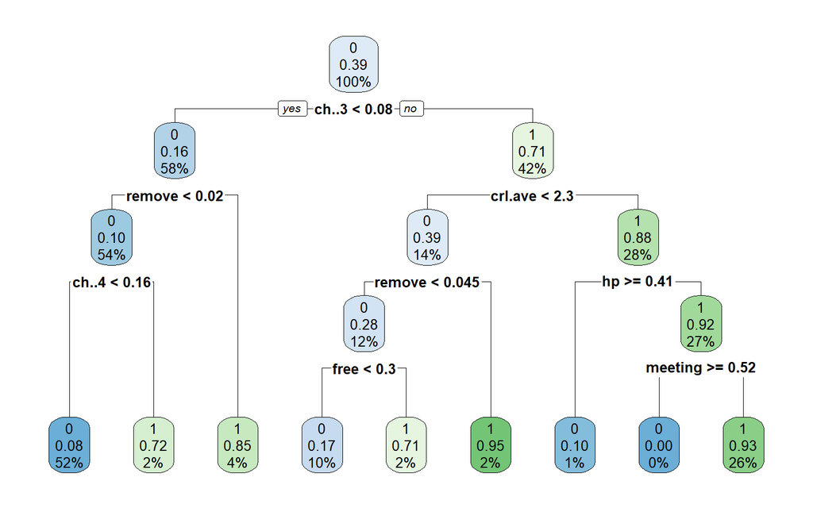

```r
rpart.plot(spam_tree)
```

```r
printcp(spam_tree)
```

```
##
## Classification tree:
## rpart(formula = spam ~ ., data = spam_train, method = "class")
##
## Variables actually used in tree construction:
## [1] ch..3   ch..4   crl.ave free    hp      meeting remove
##
## Root node error: 1360/3451 = 0.39409
##
## n= 3451
##
##         CP nsplit rel error  xerror     xstd
## 1 0.460294      0   1.00000 1.00000 0.021107
## 2 0.081618      1   0.53971 0.57500 0.018083
## 3 0.075735      2   0.45809 0.47279 0.016819
## 4 0.052206      3   0.38235 0.41765 0.016017
## 5 0.026471      4   0.33015 0.32941 0.014518
## 6 0.025000      5   0.30368 0.31029 0.014151
## 7 0.021324      6   0.27868 0.30368 0.014020
## 8 0.011765      7   0.25735 0.28456 0.013630
## 9 0.010000      8   0.24559 0.26471 0.013204
```

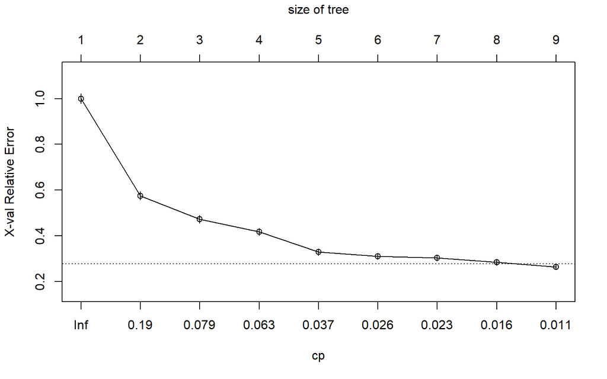

```r
plotcp(spam_tree) # visualize cross-validation results
```

```r
summary(spam_tree) # detailed summary of splits
```

```
## Call:
## rpart(formula = spam ~ ., data = spam_train, method = "class")
##   n= 3451
##
##           CP nsplit rel error    xerror       xstd
## 1 0.46029412      0 1.0000000 1.0000000 0.02110742
## 2 0.08161765      1 0.5397059 0.5750000 0.01808282
## 3 0.07573529      2 0.4580882 0.4727941 0.01681871
## 4 0.05220588      3 0.3823529 0.4176471 0.01601714
## 5 0.02647059      4 0.3301471 0.3294118 0.01451795
## 6 0.02500000      5 0.3036765 0.3102941 0.01415124
## 7 0.02132353      6 0.2786765 0.3036765 0.01402031
## 8 0.01176471      7 0.2573529 0.2845588 0.01362977
## 9 0.01000000      8 0.2455882 0.2647059 0.01320351
##
## Variable importance
##    ch..3 crl.long   remove    ch..4     free  crl.ave     your      all
##       25       11       10       10        9        8        7        6
##       hp  crl.tot      hpl  meeting     labs     X650   george     X000
##        3        3        2        1        1        1        1        1
##
## Node number 1: 3451 observations,    complexity param=0.4602941
##   predicted class=0  expected loss=0.3940887  P(node) =1
##     class counts:  2091  1360
##    probabilities: 0.606 0.394
##   left son=2 (1995 obs) right son=3 (1456 obs)
##   Primary splits:
##       ch..3  < 0.0795 to the left,  improve=518.6677, (0 missing)
##       ch..4  < 0.0395 to the left,  improve=514.2135, (0 missing)
##       remove < 0.01   to the left,  improve=455.7579, (0 missing)
##       free   < 0.075  to the left,  improve=407.5182, (0 missing)
##       your   < 0.605  to the left,  improve=396.5767, (0 missing)
##   Surrogate splits:
##       free     < 0.135  to the left,  agree=0.701, adj=0.291, (0 split)
##       ch..4    < 0.0535 to the left,  agree=0.701, adj=0.291, (0 split)
##       your     < 0.595  to the left,  agree=0.697, adj=0.283, (0 split)
##       crl.long < 53.5   to the left,  agree=0.680, adj=0.240, (0 split)
##       all      < 0.265  to the left,  agree=0.676, adj=0.233, (0 split)
##
## Node number 2: 1995 observations,    complexity param=0.07573529
```

[output cut: 148 more lines]

```
##
## Node number 25: 86 observations
##   predicted class=1  expected loss=0.2906977  P(node) =0.02492031
##     class counts:    25    61
##    probabilities: 0.291 0.709
##
## Node number 30: 16 observations
##   predicted class=0  expected loss=0  P(node) =0.004636337
##     class counts:    16     0
##    probabilities: 1.000 0.000
##
## Node number 31: 905 observations
##   predicted class=1  expected loss=0.06519337  P(node) =0.2622428
##     class counts:    59   846
##    probabilities: 0.065 0.935
```

Maintenat on “prunge” l’arbre en determinant le meilleur xerror et ecart type et le meilleur arbre

```r
index_best <- which.min(spam_tree$cptable[,"xerror"])
xerror <- spam_tree$cptable[index_best,"xerror"]
std <- spam_tree$cptable[index_best,"xstd"]
```

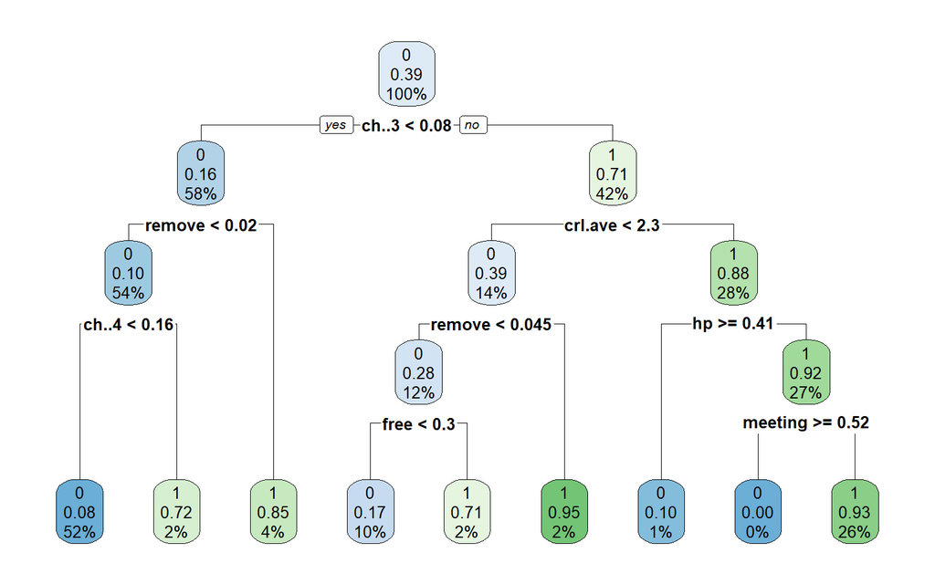

```r
spam_tree <- prune(spam_tree,cp= 0.01092896) # On choisit le cptable pour lequel xerror < xerror_target
rpart.plot(spam_tree)
```

# Bagging

```r
n_pred <- ncol(spam) - 1
bagged_model <- randomForest(spam~., data = spam_train, mrty = n_pred, importance = TRUE)
summary(bagged_model)
```

```
##                 Length Class  Mode
## call               5   -none- call
## type               1   -none- character
## predicted       3451   -none- numeric
## mse              500   -none- numeric
## rsq              500   -none- numeric
## oob.times       3451   -none- numeric
## importance       114   -none- numeric
## importanceSD      57   -none- numeric
## localImportance    0   -none- NULL
## proximity          0   -none- NULL
## ntree              1   -none- numeric
## mtry               1   -none- numeric
## forest            11   -none- list
## coefs              0   -none- NULL
## y               3451   -none- numeric
## test               0   -none- NULL
## inbag              0   -none- NULL
## terms              3   terms  call
```

#Random Forest

```r
rf_model <- randomForest(spam~., data = spam_train, importance = TRUE)
summary(rf_model)
```

```
##                 Length Class  Mode
## call               4   -none- call
## type               1   -none- character
## predicted       3451   -none- numeric
## mse              500   -none- numeric
## rsq              500   -none- numeric
## oob.times       3451   -none- numeric
## importance       114   -none- numeric
## importanceSD      57   -none- numeric
## localImportance    0   -none- NULL
## proximity          0   -none- NULL
## ntree              1   -none- numeric
## mtry               1   -none- numeric
## forest            11   -none- list
## coefs              0   -none- NULL
## y               3451   -none- numeric
## test               0   -none- NULL
## inbag              0   -none- NULL
## terms              3   terms  call
```

# Gradient Boost

```r
gbm_model <- gbm(spam~., data = spam_train, distribution = "bernoulli" ,n.trees = 5000, interaction.depth = 6, shrinkage = 0.01)
```

#Prediction

```r
proba_predict <- predict(logistik_model, newdata = spam_test ,type =  "response")
summary(proba_predict)
```

```
##     Min.  1st Qu.   Median     Mean  3rd Qu.     Max.
## 0.000000 0.001014 0.171568 0.399455 0.930955 1.000000
```

#Arbre de classification

```r
tree_predict <- predict(spam_tree, spam_test, type = "class")
summary(tree_predict)
```

```
##   0   1
## 724 426
```

#Bagged model

```r
bagged_predict <- predict(bagged_model, spam_test, type = "response")
summary(bagged_predict)
```

```
##    Min. 1st Qu.  Median    Mean 3rd Qu.    Max.
## 0.00000 0.01753 0.13697 0.39397 0.93018 1.00000
```

#Random Forest

```r
rf_predict <- predict(rf_model, spam_test, type = "response")
summary(rf_predict)
```

```
##    Min. 1st Qu.  Median    Mean 3rd Qu.    Max.
## 0.00000 0.01797 0.13872 0.39402 0.92748 1.00000
```

# GBM

```r
gbm_predict <- predict(gbm_model, spam_test, type = "response")
```

```
## Using 5000 trees...
```

# Matrice confusion

```r
Observations <- spam_test$spam
head(Observations)
```

```
## [1] 1 1 1 1 1 1
```

```r
p_test <- ifelse(proba_predict > 0.5, 1,0)
M_conf_logistik <- confusionMatrix(table(Observations,p_test))
M_conf_logistik
```

```
## Confusion Matrix and Statistics
##
##             p_test
## Observations   0   1
##            0 656  41
##            1  51 402
##
##                Accuracy : 0.92
##                  95% CI : (0.9028, 0.935)
##     No Information Rate : 0.6148
##     P-Value [Acc > NIR] : <2e-16
##
##                   Kappa : 0.8318
##
##  Mcnemar's Test P-Value : 0.3481
##
##             Sensitivity : 0.9279
##             Specificity : 0.9074
##          Pos Pred Value : 0.9412
##          Neg Pred Value : 0.8874
##              Prevalence : 0.6148
##          Detection Rate : 0.5704
##    Detection Prevalence : 0.6061
##       Balanced Accuracy : 0.9177
##
##        'Positive' Class : 0
##
```

# Classification

```r
M_conf_class <-confusionMatrix(table(Observations,tree_predict))
M_conf_class
```

```
## Confusion Matrix and Statistics
##
##             tree_predict
## Observations   0   1
##            0 650  47
##            1  74 379
##
##                Accuracy : 0.8948
##                  95% CI : (0.8756, 0.9119)
##     No Information Rate : 0.6296
##     P-Value [Acc > NIR] : <2e-16
##
##                   Kappa : 0.7773
##
##  Mcnemar's Test P-Value : 0.0181
##
##             Sensitivity : 0.8978
##             Specificity : 0.8897
##          Pos Pred Value : 0.9326
##          Neg Pred Value : 0.8366
##              Prevalence : 0.6296
##          Detection Rate : 0.5652
##    Detection Prevalence : 0.6061
##       Balanced Accuracy : 0.8937
##
##        'Positive' Class : 0
##
```

#Bagged

```r
M_conf_bagged <-confusionMatrix(table(Observations,ifelse(bagged_predict<0.5,0,1)))
M_conf_bagged
```

```
## Confusion Matrix and Statistics
##
##
## Observations   0   1
##            0 676  21
##            1  40 413
##
##                Accuracy : 0.947
##                  95% CI : (0.9324, 0.9592)
##     No Information Rate : 0.6226
##     P-Value [Acc > NIR] : < 2e-16
##
##                   Kappa : 0.8881
##
##  Mcnemar's Test P-Value : 0.02119
##
##             Sensitivity : 0.9441
##             Specificity : 0.9516
##          Pos Pred Value : 0.9699
##          Neg Pred Value : 0.9117
##              Prevalence : 0.6226
##          Detection Rate : 0.5878
##    Detection Prevalence : 0.6061
##       Balanced Accuracy : 0.9479
##
##        'Positive' Class : 0
##
```

#Random Forest

```r
M_conf_RandomForest <-confusionMatrix(table(Observations,ifelse(rf_predict<0.5,0,1)))
M_conf_RandomForest
```

```
## Confusion Matrix and Statistics
##
##
## Observations   0   1
##            0 677  20
##            1  39 414
##
##                Accuracy : 0.9487
##                  95% CI : (0.9343, 0.9607)
##     No Information Rate : 0.6226
##     P-Value [Acc > NIR] : < 2e-16
##
##                   Kappa : 0.8918
##
##  Mcnemar's Test P-Value : 0.01911
##
##             Sensitivity : 0.9455
##             Specificity : 0.9539
##          Pos Pred Value : 0.9713
##          Neg Pred Value : 0.9139
##              Prevalence : 0.6226
##          Detection Rate : 0.5887
##    Detection Prevalence : 0.6061
##       Balanced Accuracy : 0.9497
##
##        'Positive' Class : 0
##
```

#GBM

```r
M_conf_gbm <-confusionMatrix(table(Observations,ifelse(gbm_predict<0.5,0,1)))
M_conf_gbm
```

```
## Confusion Matrix and Statistics
##
##
## Observations   0   1
##            0 673  24
##            1  33 420
##
##                Accuracy : 0.9504
##                  95% CI : (0.9363, 0.9622)
##     No Information Rate : 0.6139
##     P-Value [Acc > NIR] : <2e-16
##
##                   Kappa : 0.8958
##
##  Mcnemar's Test P-Value : 0.2893
##
##             Sensitivity : 0.9533
##             Specificity : 0.9459
##          Pos Pred Value : 0.9656
##          Neg Pred Value : 0.9272
##              Prevalence : 0.6139
##          Detection Rate : 0.5852
##    Detection Prevalence : 0.6061
##       Balanced Accuracy : 0.9496
##
##        'Positive' Class : 0
##
```

# Performance des modèles

```r
accuracy = function(pred, obs)
{
  mean(pred == obs)
}

logist_acc <- accuracy(spam_test$spam,p_test)
tree_acc <- accuracy(spam_test$spam,tree_predict)
bagged_acc <- accuracy(spam_test$spam,ifelse(bagged_predict<0.5,0,1))
rf_acc <- accuracy(spam_test$spam,ifelse(rf_predict<0.5,0,1))
gbm_acc <- accuracy(spam_test$spam,ifelse(gbm_predict<0.5,0,1))

acc_compare <- c(logistic = logist_acc, tree =tree_acc, bagged = bagged_acc, randomForest = rf_acc, Gradient_boost = gbm_acc)
acc_compare
```

```
##       logistic           tree         bagged   randomForest Gradient_boost
##      0.9200000      0.8947826      0.9469565      0.9486957      0.9504348
```

##Optimisation

```r
spam_train$spam <- factor(spam_train$spam,levels = c("0","1"), labels =c("0", "1"))

control <- trainControl(method = "oob")

grid <- expand.grid(mtry = (1:8))

rf_tuning <- train(spam ~ ., data = spam_train, method = "rf",
                   metric = "Accuracy", trControl = control, tuneGrid = grid)
summary(rf_tuning)
```

```
##                 Length Class      Mode
## call               4   -none-     call
## type               1   -none-     character
## predicted       3451   factor     numeric
## err.rate        1500   -none-     numeric
## confusion          6   -none-     numeric
## votes           6902   matrix     numeric
## oob.times       3451   -none-     numeric
## classes            2   -none-     character
## importance        57   -none-     numeric
## importanceSD       0   -none-     NULL
## localImportance    0   -none-     NULL
## proximity          0   -none-     NULL
## ntree              1   -none-     numeric
## mtry               1   -none-     numeric
## forest            14   -none-     list
## y               3451   factor     numeric
## test               0   -none-     NULL
## inbag              0   -none-     NULL
## xNames            57   -none-     character
## problemType        1   -none-     character
## tuneValue          1   data.frame list
## obsLevels          2   -none-     character
## param              0   -none-     list
```

```r
pred_rft <- predict(rf_tuning, spam_test)
accuracy_rft <- accuracy(spam_test$spam, pred_rft)
accuracy_rft
```

```
## [1] 0.9513043
```

```r
data.frame(
  model = c("Logistic Regression", "Classification Tree", "Bagging", "Random Forest", "Boosting", "Tuned Random Forest"),
  accuracy = c(logist_acc, tree_acc, bagged_acc, rf_acc, gbm_acc, accuracy_rft)
)
```

```
##                 model  accuracy
## 1 Logistic Regression 0.9200000
## 2 Classification Tree 0.8947826
## 3             Bagging 0.9469565
## 4       Random Forest 0.9486957
## 5            Boosting 0.9504348
## 6 Tuned Random Forest 0.9513043
```

#Boosting

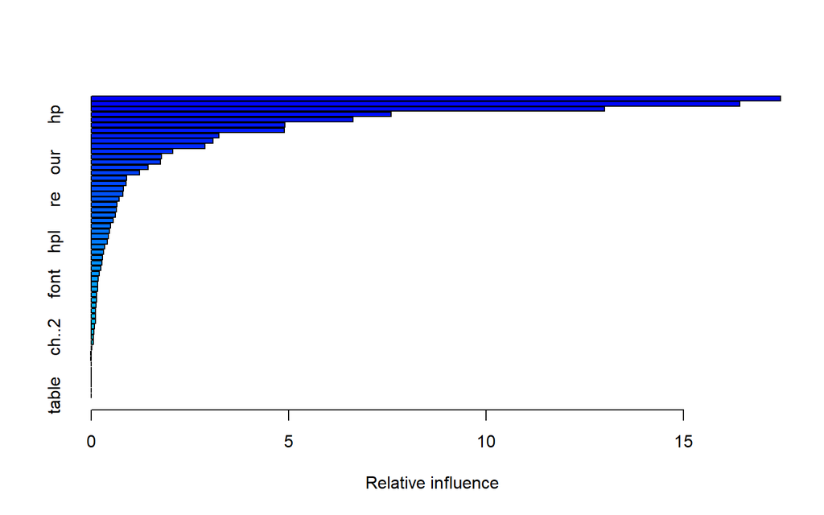

```
##                   var      rel.inf
## ch..3           ch..3 17.453447083
## ch..4           ch..4 16.419373543
## remove         remove 13.005977641
## hp                 hp  7.592189542
## crl.ave       crl.ave  6.628544893
## your             your  4.901555223
## free             free  4.897669514
## crl.tot       crl.tot  3.235178741
## crl.long     crl.long  3.091008522
## edu               edu  2.878990908
## george         george  2.073718486
## money           money  1.784634854
## our               our  1.760765989
## you               you  1.439777336
## X000             X000  1.220946580
## X650             X650  0.900772306
## will             will  0.892169218
## email           email  0.817275201
## ch..1           ch..1  0.808616097
## re                 re  0.705429270
## meeting       meeting  0.654622091
## mail             mail  0.636427236
## receive       receive  0.619690991
## X1999           X1999  0.554986795
## internet     internet  0.498440512
## ch.               ch.  0.470510791
## people         people  0.441058793
## hpl               hpl  0.405706893
## all               all  0.345384619
## report         report  0.312904329
## business     business  0.285307244
## over             over  0.267710130
## make             make  0.249785050
## technology technology  0.210350203
## X3d               X3d  0.176455747
## font             font  0.169116018
## address       address  0.167412350
## data             data  0.133666989
## pm                 pm  0.132733007
## order           order  0.123217711
## project       project  0.116095802
## ch..5           ch..5  0.107668502
## labs             labs  0.106355466
## conference conference  0.079029853
## credit         credit  0.072979624
## ch..2           ch..2  0.060486277
## direct         direct  0.052913662
## original     original  0.016353477
## X85               X85  0.007592675
## addresses   addresses  0.007169550
## lab               lab  0.006033492
## parts           parts  0.002337345
## cs                 cs  0.001455826
## telnet         telnet  0.000000000
## X857             X857  0.000000000
## X415             X415  0.000000000
## table           table  0.000000000
```

```r
control <- trainControl(method = "cv", number = 10)

grid <- expand.grid(n.trees = c(100, 500),
                    interaction.depth = c(2, 4, 6),
                    n.minobsinnode = c(3, 5, 10),
                    shrinkage = c(.1, .01, .001))

gbm_tuning <- train(spam ~ ., data = spam_train, method = "gbm",
                    metric = "Accuracy", trControl = control, tuneGrid = grid,
                    verbose = FALSE)
summary(gbm_tuning)
```

```r
pred_gbmt <- predict(gbm_tuning, spam_test)
accuracy_gbmt <- accuracy(spam_test$spam, pred_gbmt)
accuracy_gbmt
```

```
## [1] 0.9486957
```

```r
data.frame(
  model = c("Logistic Regression", "Classification Tree", "Bagging", "Random Forest", "Boosting", "Tuned Random Forest", "Tuned Boosting"),
  accuracy = c(logist_acc, tree_acc, bagged_acc, rf_acc, gbm_acc, accuracy_rft, accuracy_gbmt)
)
```

```
##                 model  accuracy
## 1 Logistic Regression 0.9200000
## 2 Classification Tree 0.8947826
## 3             Bagging 0.9469565
## 4       Random Forest 0.9486957
## 5            Boosting 0.9504348
## 6 Tuned Random Forest 0.9513043
## 7      Tuned Boosting 0.9486957
```